# ANALYSIS OF TITANIC INCIDENT

# INTRODUCTORY:

TITANIC was an British passenger liner which was collided with an iceberg during her maiden voyage from Southampton to Newyork city resulting in sink to the bottom of North Atlantic Ocean in the year 1912. Approximately 2224 passengers were aboard the ship. These ship includes embarkation point in Cherbourg and Queenstown. We are going to anlayze these incident with a dataset of 891 passengers.

```python
# importing all libraries
import pandas as pd
import numpy as np
import seaborn as sns
import matplotlib.pyplot as plt
```

```python
#Loading files and converting it into DataFrame
file_name = pd.read_csv('C:/Users/This/Desktop/TITANIC/titanic-data.csv')
titanic_df = pd.DataFrame(file_name)
```

# CONSIDERING DATA:

```python
titanic_df.head()
```

|  | PassengerId | Survived | Pclass | Name | Sex | Age | SibSp | Parch | Ticket | Fare | Cabin | Embarked |
| --- | --- | --- | --- | --- | --- | --- | --- | --- | --- | --- | --- | --- |
| 0 | 1 | 0 | 3 | Braund, Mr. Owen Harris | male | 22.0 | 1 | 0 | A/5 21171 | 7.2500 | NaN | S |
| 1 | 2 | 1 | 1 | Cumings, Mrs. John Bradley (Florence Briggs Th... | female | 38.0 | 1 | 0 | PC 17599 | 71.2833 | C85 | C |
| 2 | 3 | 1 | 3 | Heikkinen, Miss. Laina | female | 26.0 | 0 | 0 | STON/O2. 3101282 | 7.9250 | NaN | S |
| 3 | 4 | 1 | 1 | Futrelle, Mrs. Jacques Heath (Lily May Peel) | female | 35.0 | 1 | 0 | 113803 | 53.1000 | C123 | S |
| 4 | 5 | 0 | 3 | Allen, Mr. William Henry | male | 35.0 | 0 | 0 | 373450 | 8.0500 | NaN | S |

# DESCRIBING THE DATA:

DATA DICTIONARY:

survival - Survival  
pclass - Ticket class  
sex - Sex  
Age - Age in years  
sibsp - # of siblings / spouses aboard the Titanic  
parch - # of parents / children aboard the Titanic  
ticket - Ticket number  
fare - Passenger fare  
cabin - Cabin number  
embarked - Port of Embarkation

KEY:

survival:  
0 = NO  
1 = YES

Pclass: 1 = 1st, 2 = 2nd, 3 = 3rd

port: C = Cherbourg, Q = Queenstown, S = Southampton

# ANALYZING QUESTIONS FROM DATA:

1) How many passengers survived from the titanic?

2) Which level of class passengers survived the most?

3) How many of male passengers and female passengers survived?

4) From the above analysis which gender of passengers survived the most?

5) How many passengers survived below the age of 10?

6) Which age group of passengers survived the most?

7) How many passengers are travelling with their SibSp and Parch?

8) How many families survived?

9) Who were the passengers travelling with the highest ticket fare and lowest fare?

10) Which port of embarkation has an higher number of passengers survived?

```python
#Calculating functions required:
titanic_df.describe()
```

|  | PassengerId | Survived | Pclass | Age | SibSp | Parch | Fare |
| --- | --- | --- | --- | --- | --- | --- | --- |
| count | 891.000000 | 891.000000 | 891.000000 | 714.000000 | 891.000000 | 891.000000 | 891.000000 |
| mean | 446.000000 | 0.383838 | 2.308642 | 29.699118 | 0.523008 | 0.381594 | 32.204208 |
| std | 257.353842 | 0.486592 | 0.836071 | 14.526497 | 1.102743 | 0.806057 | 49.693429 |
| min | 1.000000 | 0.000000 | 1.000000 | 0.420000 | 0.000000 | 0.000000 | 0.000000 |
| 25% | 223.500000 | 0.000000 | 2.000000 | 20.125000 | 0.000000 | 0.000000 | 7.910400 |
| 50% | 446.000000 | 0.000000 | 3.000000 | 28.000000 | 0.000000 | 0.000000 | 14.454200 |
| 75% | 668.500000 | 1.000000 | 3.000000 | 38.000000 | 1.000000 | 0.000000 | 31.000000 |
| max | 891.000000 | 1.000000 | 3.000000 | 80.000000 | 8.000000 | 6.000000 | 512.329200 |

From the above table we observe the total number of passsengers are 891 except at the age column. There are only 714 passengers age included in the data. So we need to find the number of passengers who doesnt have included their age in the data. So we use Data Cleaning process inorder to solve this missing ages.

# Data Cleaning Process:

```python
# Finding part in missing Data:
titanic_df.isnull()
```

[output not shown]

891 rows × 12 columns

The table with 'True' word indicates that there is no value mentioned in the data. In this Data some part of age,cabin and embarked related data founds to be missing.

```python
# finding the count of missing data:
titanic_df.isnull().sum()
```

```
PassengerId      0
Survived         0
Pclass           0
Name             0
Sex              0
Age            177
SibSp            0
Parch            0
Ticket           0
Fare             0
Cabin          687
Embarked         2
dtype: int64
```

There are 177 passengers "age" followed by 687 passengers "cabin number" and 2 passengers "port of embarkation" seems to be missing in the data.

```python
# filling the "age" related missing data:
mean = titanic_df['Age'].mean()
print mean
```

```
29.6991176471
```

```python
titanic_df['Age'].fillna(mean,inplace=True)
print titanic_df['Age'].describe()
```

```
count    891.000000
mean      29.699118
std       13.002015
min        0.420000
25%       22.000000
50%       29.699118
75%       35.000000
max       80.000000
Name: Age, dtype: float64
```

we solve the missing values issue in the 'Age' related Data by filling the mean age in the entire missing age of passengers. Now our Data seems to be 891 passengers in entire column.

```python
titanic_df.describe()
```

|  | PassengerId | Survived | Pclass | Age | SibSp | Parch | Fare |
| --- | --- | --- | --- | --- | --- | --- | --- |
| count | 891.000000 | 891.000000 | 891.000000 | 891.000000 | 891.000000 | 891.000000 | 891.000000 |
| mean | 446.000000 | 0.383838 | 2.308642 | 29.699118 | 0.523008 | 0.381594 | 32.204208 |
| std | 257.353842 | 0.486592 | 0.836071 | 13.002015 | 1.102743 | 0.806057 | 49.693429 |
| min | 1.000000 | 0.000000 | 1.000000 | 0.420000 | 0.000000 | 0.000000 | 0.000000 |
| 25% | 223.500000 | 0.000000 | 2.000000 | 22.000000 | 0.000000 | 0.000000 | 7.910400 |
| 50% | 446.000000 | 0.000000 | 3.000000 | 29.699118 | 0.000000 | 0.000000 | 14.454200 |
| 75% | 668.500000 | 1.000000 | 3.000000 | 35.000000 | 1.000000 | 0.000000 | 31.000000 |
| max | 891.000000 | 1.000000 | 3.000000 | 80.000000 | 8.000000 | 6.000000 | 512.329200 |

Now we can observe that every column consists of 891 passngers.

```python
# Finding missing values in cabin number and embarked:
titanic_df['Cabin'].fillna('unknown',inplace=True)
print titanic_df['Cabin']
titanic_df['Embarked'].fillna('unknown',inplace=True)
print titanic_df['Embarked']
```

[output not shown]

[output cut: 109 more lines]

# Exploring the Data:

1) How many passengers survived from the titanic?

```python
print 'Number of passengers Survived are',len(titanic_df.loc[titanic_df['Survived']==1])
```

```
Number of passengers Survived are 342
```

The Number of passengers survived from the titanic are 342.

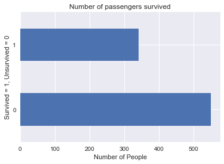

```python
p = titanic_df['Survived'].value_counts().plot(kind='barh')
p.set_xlabel('Number of People')
p.set_ylabel('Survived = 1, Unsurvived = 0')
p.set_title("Number of passengers survived")
plt.show()
```

From the above visualization we can observe the number of persons survived is between 300 to 350. We have analyzed the number of persons survived = 342 is correct.

2) Which level of class passengers survived the most?

2.1) How many number of passengers travelling in each class?

```python
print 'Number of passengers travelling in 1st class',len(titanic_df.loc[titanic_df['Pclass']==1])
print 'Number of passengers travelling in 2nd class',len(titanic_df.loc[titanic_df['Pclass']==2])
print 'Number of passengers travelling in 3rd class',len(titanic_df.loc[titanic_df['Pclass']==3])
```

```
Number of passengers travelling in 1st class 216
Number of passengers travelling in 2nd class 184
Number of passengers travelling in 3rd class 491
```

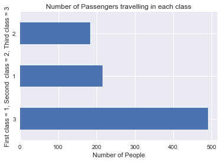

```python
p = titanic_df['Pclass'].value_counts().plot(kind='barh')
p.set_xlabel('Number of People')
p.set_ylabel('First class = 1, Second  class = 2, Third class = 3')
p.set_title("Number of Passengers travelling in each class")
plt.show()
```

From the above visualization we can observe the number of persons travelling based on each Pclass.

2.2) How many number of passengers survived in each class?

```python
# Number of passengers survived in each class:
print 'Number of passengers survived travelling in each',titanic_df.groupby('Pclass')['Survived'].sum()
```

```
Number of passengers survived travelling in each Pclass
1    136
2     87
3    119
Name: Survived, dtype: int64
```

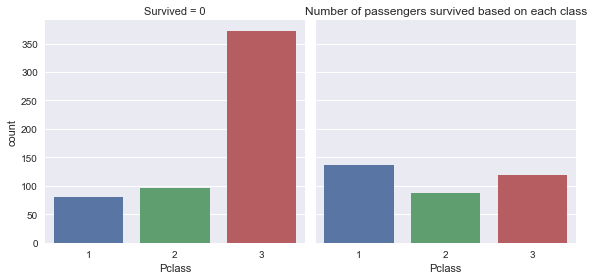

```python
sns.factorplot(x='Pclass', col='Survived', data=titanic_df, kind='count');
plt.title('Number of passengers survived based on each class')
plt.show()
```

From the analysis we observe that the maximum number of passengers survived were travelling in class 1.

2.3) Which class has the higher number of survivals?

```python
print 'The maximum number of passengers survived is in class',titanic_df.groupby('Pclass')['Survived'].sum().argmax()
```

```
The maximum number of passengers survived is in class 1
```

3) How many of male passengers and female passengers survived?

3.1) How many number of male passengers and female passengers are travelling?

```python
# Number of passengers travelling based on Sex:
print 'Number of male passengers travelling are',len(titanic_df.loc[titanic_df['Sex']=='male'])
print 'Number of female passengers travelling are', len(titanic_df.loc[titanic_df['Sex']=='female'])
```

```
Number of male passengers travelling are 577
Number of female passengers travelling are 314
```

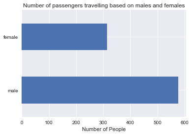

```python
p = titanic_df['Sex'].value_counts().plot(kind='barh')
p.set_xlabel('Number of People')
p.set_title("Number of passengers travelling based on males and females")
plt.show()
```

From the analysis we can observe the male passengers are travelling more than the female passengers in the titanic.

3.2) How many number of male passengers and female passengers are survived?

```python
# Number of passengers Survived based on Sex:
print 'Number of passengers survived based on',titanic_df.groupby('Sex')['Survived'].sum()
```

```
Number of passengers survived based on Sex
female    233
male      109
Name: Survived, dtype: int64
```

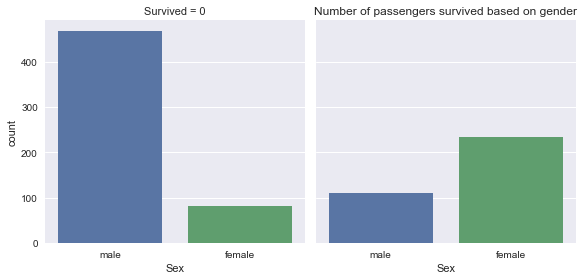

```python
sns.factorplot(x='Sex', col='Survived', data=titanic_df, kind='count');
plt.title('Number of passengers survived based on gender')
plt.show()
```

From the analysis it seems that the female passengers are more survived compared to the male passengers.

4) From the above analysis which gender of passengers survived the most?

```python
# Maximum number of passengers survived the most based on Sex:
print 'Maximum number of passengers survived the most based on Sex are',titanic_df.groupby('Sex')['Survived'].sum().argmax()
```

```
Maximum number of passengers survived the most based on Sex are female
```

5) How many passengers survived below the age of 10?

5.1) How many passengers are travelling below the age of 10?

```python
# Passengers travelling below age of 10:
print 'passengers travelling below age of 10 are',len(titanic_df.loc[titanic_df['Age']<10])
```

```
passengers travelling below age of 10 are 62
```

5.2) How many passengers survived below the age of 10?

```python
# Passengers Survived below age of 10:
print 'Passengers survived below the age of 10 are',titanic_df.groupby(titanic_df['Age']<=10)['Survived'].sum()
```

```
Passengers survived below the age of 10 are Age
False    304
True      38
Name: Survived, dtype: int64
```

6) Which age group of passengers survived the most?

[figure not shown]

```python
%matplotlib inline
age_bins = np.arange(0,100,10)
sns.distplot(titanic_df.loc[(titanic_df['Survived']==0) & (~titanic_df['Age'].isnull()),'Age'],bins=age_bins)
sns.distplot(titanic_df.loc[(titanic_df['Survived']==1) & (~titanic_df['Age'].isnull()),'Age'],bins=age_bins)
plt.legend(['passengers survived','passengers not survived']);
plt.title('Group of passengers survived according to their age')
plt.ylabel('frequency')
```

So by this plotting analyis we came to certain conclusions:

7) How many passengers are travelling with their SibSp and Parch?

7.1) How passengers have their sibsp travelling?

```python
# Passengers who have their sibsp travelling:
print 'Passengers having their sibsp travelling in ship are',len(titanic_df.loc[titanic_df['SibSp']>=1])
```

```
Passengers having their sibsp travelling in ship are 283
```

7.2) How passengers have their Parch travelling?

```python
# Passengers who have their parch travelling:-
print 'passengers having their parch travelling in ship are',len(titanic_df.loc[titanic_df['Parch']>=1])
```

```
passengers having their parch travelling in ship are 213
```

There are 283 passengers travelling with their Sibsp and 213 passengers travelling with their parch.

8) How many families survived?

```python
# Number of families survived based on SibSp and Parch:
print 'Number of families survived based on', titanic_df.groupby(titanic_df['SibSp']>=1)['Survived'].sum()
print 'Number of families survived based on', titanic_df.groupby(titanic_df['Parch']>=1)['Survived'].sum()
a = titanic_df.groupby(titanic_df['SibSp']>=1)['Survived'].sum()
b = titanic_df.groupby(titanic_df['Parch']>=1)['Survived'].sum()
print 'Total number of families survived are', a+b
```

```
Number of families survived based on SibSp
False    210
True     132
Name: Survived, dtype: int64
Number of families survived based on Parch
False    233
True     109
Name: Survived, dtype: int64
Total number of families survived are SibSp
False    443
True     241
Name: Survived, dtype: int64
```

From the above analysis Number of families survived based on SibSp are 132 Number of families survuved based on Parch are 109 so Total number of families survived travelling in titanic are 241

9) Who were the passengers travelling with the highest ticket fare and lowest fare?

9.1) Who were the passengers travelling with the highest fare?

```python
titanic_df.loc[titanic_df['Fare'] == titanic_df['Fare'].max()]
```

|  | PassengerId | Survived | Pclass | Name | Sex | Age | SibSp | Parch | Ticket | Fare | Cabin | Embarked |
| --- | --- | --- | --- | --- | --- | --- | --- | --- | --- | --- | --- | --- |
| 258 | 259 | 1 | 1 | Ward, Miss. Anna | female | 35.0 | 0 | 0 | PC 17755 | 512.3292 | unknown | C |
| 679 | 680 | 1 | 1 | Cardeza, Mr. Thomas Drake Martinez | male | 36.0 | 0 | 1 | PC 17755 | 512.3292 | B51 B53 B55 | C |
| 737 | 738 | 1 | 1 | Lesurer, Mr. Gustave J | male | 35.0 | 0 | 0 | PC 17755 | 512.3292 | B101 | C |

9.2) Who were the passengers travelling with the lowest fare?

```python
titanic_df.loc[titanic_df['Fare'] == titanic_df['Fare'].min()]
```

|  | PassengerId | Survived | Pclass | Name | Sex | Age | SibSp | Parch | Ticket | Fare | Cabin | Embarked |
| --- | --- | --- | --- | --- | --- | --- | --- | --- | --- | --- | --- | --- |
| 179 | 180 | 0 | 3 | Leonard, Mr. Lionel | male | 36.000000 | 0 | 0 | LINE | 0.0 | unknown | S |
| 263 | 264 | 0 | 1 | Harrison, Mr. William | male | 40.000000 | 0 | 0 | 112059 | 0.0 | B94 | S |
| 271 | 272 | 1 | 3 | Tornquist, Mr. William Henry | male | 25.000000 | 0 | 0 | LINE | 0.0 | unknown | S |
| 277 | 278 | 0 | 2 | Parkes, Mr. Francis "Frank" | male | 29.699118 | 0 | 0 | 239853 | 0.0 | unknown | S |
| 302 | 303 | 0 | 3 | Johnson, Mr. William Cahoone Jr | male | 19.000000 | 0 | 0 | LINE | 0.0 | unknown | S |
| 413 | 414 | 0 | 2 | Cunningham, Mr. Alfred Fleming | male | 29.699118 | 0 | 0 | 239853 | 0.0 | unknown | S |
| 466 | 467 | 0 | 2 | Campbell, Mr. William | male | 29.699118 | 0 | 0 | 239853 | 0.0 | unknown | S |
| 481 | 482 | 0 | 2 | Frost, Mr. Anthony Wood "Archie" | male | 29.699118 | 0 | 0 | 239854 | 0.0 | unknown | S |
| 597 | 598 | 0 | 3 | Johnson, Mr. Alfred | male | 49.000000 | 0 | 0 | LINE | 0.0 | unknown | S |
| 633 | 634 | 0 | 1 | Parr, Mr. William Henry Marsh | male | 29.699118 | 0 | 0 | 112052 | 0.0 | unknown | S |
| 674 | 675 | 0 | 2 | Watson, Mr. Ennis Hastings | male | 29.699118 | 0 | 0 | 239856 | 0.0 | unknown | S |
| 732 | 733 | 0 | 2 | Knight, Mr. Robert J | male | 29.699118 | 0 | 0 | 239855 | 0.0 | unknown | S |
| 806 | 807 | 0 | 1 | Andrews, Mr. Thomas Jr | male | 39.000000 | 0 | 0 | 112050 | 0.0 | A36 | S |
| 815 | 816 | 0 | 1 | Fry, Mr. Richard | male | 29.699118 | 0 | 0 | 112058 | 0.0 | B102 | S |
| 822 | 823 | 0 | 1 | Reuchlin, Jonkheer. John George | male | 38.000000 | 0 | 0 | 19972 | 0.0 | unknown | S |

There are a total of 3 passengers travelling with an highest fare of 512.3292 and also there are 15 passengers travelling with an lowest fare of 0.0

10) Which port of embarkation has an higher number of passengers survived?

10.1) How many passengers are travelling in each ports?

```python
# Number of passengers embarked in ports:
print 'Number of passengers embarked in port S are', len(titanic_df.loc[titanic_df['Embarked']=='S'])
print 'Number of passengers embarked in port C are', len(titanic_df.loc[titanic_df['Embarked']=='C'])
print 'Number of passengers embarked in port Q are', len(titanic_df.loc[titanic_df['Embarked']=='Q'])
```

```
Number of passengers embarked in port S are 644
Number of passengers embarked in port C are 168
Number of passengers embarked in port Q are 77
```

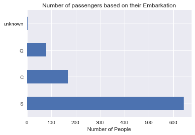

```python
p = titanic_df['Embarked'].value_counts().plot(kind='barh')
p.set_xlabel('Number of People')
p.set_title('Number of passengers based on their Embarkation')
plt.show()
```

From the above visualization we observe more number of people embarked through port S.

10.2) How many passengers survived in each ports?

```python
# Number of passengers Survived:
print 'Number of passengers survived through the ', titanic_df.groupby('Embarked')['Survived'].sum()
```

```
Number of passengers survived through the  Embarked
C           93
Q           30
S          217
unknown      2
Name: Survived, dtype: int64
```

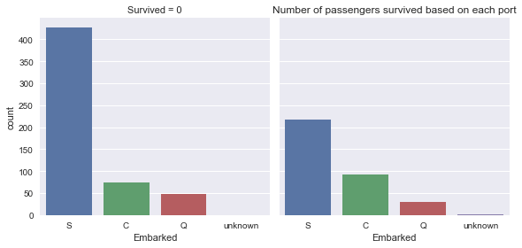

```python
sns.factorplot(x='Embarked', col='Survived', data=titanic_df, kind='count');
plt.title('Number of passengers survived based on each port')
plt.show()
```

By this visualization we came to know that the more number of passengers are survived through the port S.

10.3) Which port has the higher number of survivals?

```python
# Higher number of passengers Survived:
print 'Highest passengers survived through the port ', titanic_df.groupby('Embarked')['Survived'].sum().argmax()
```

```
Highest passengers survived through the port  S
```

# CONCLUSION:

We have gone through certain limitations in the analysis where some passengers 'Age' was missing in the data provided we have been replaced it with mean of 'Age' by Data Cleaning.

By the given data I analyzed some questions based on each of the information produced. Finally the outcome analyzed by this Data:

1) 342 passengers survived among 891 passengers.

4) Female passengers were survived more compared to the male passengers.

7) There are 283 passengers travelling with their Sibsp and 213 passengers travelling with their parch.

8) 241 families survived travelling in titanic.

9) There are a total of 3 passengers travelling with an highest fare of 512.3292 and also there are 15 passengers travelling with an lowest fare of 0.0

10) Port S has an higher survival of passengers compared to the ports Q and C.